Red Wine Exploration by Nicole Mister

========================================================

This report explores a dataset containing attributes for 1599 red wines.

# Univariate Plots Section

```
## 'data.frame':    1599 obs. of  13 variables:
##  $ X                   : int  1 2 3 4 5 6 7 8 9 10 ...
##  $ fixed.acidity       : num  7.4 7.8 7.8 11.2 7.4 7.4 7.9 7.3 7.8 7.5 ...
##  $ volatile.acidity    : num  0.7 0.88 0.76 0.28 0.7 0.66 0.6 0.65 0.58 0.5 ...
##  $ citric.acid         : num  0 0 0.04 0.56 0 0 0.06 0 0.02 0.36 ...
##  $ residual.sugar      : num  1.9 2.6 2.3 1.9 1.9 1.8 1.6 1.2 2 6.1 ...
##  $ chlorides           : num  0.076 0.098 0.092 0.075 0.076 0.075 0.069 0.065 0.073 0.071 ...
##  $ free.sulfur.dioxide : num  11 25 15 17 11 13 15 15 9 17 ...
##  $ total.sulfur.dioxide: num  34 67 54 60 34 40 59 21 18 102 ...
##  $ density             : num  0.998 0.997 0.997 0.998 0.998 ...
##  $ pH                  : num  3.51 3.2 3.26 3.16 3.51 3.51 3.3 3.39 3.36 3.35 ...
##  $ sulphates           : num  0.56 0.68 0.65 0.58 0.56 0.56 0.46 0.47 0.57 0.8 ...
##  $ alcohol             : num  9.4 9.8 9.8 9.8 9.4 9.4 9.4 10 9.5 10.5 ...
##  $ quality             : int  5 5 5 6 5 5 5 7 7 5 ...
```

```
##        X          fixed.acidity   volatile.acidity  citric.acid
##  Min.   :   1.0   Min.   : 4.60   Min.   :0.1200   Min.   :0.000
##  1st Qu.: 400.5   1st Qu.: 7.10   1st Qu.:0.3900   1st Qu.:0.090
##  Median : 800.0   Median : 7.90   Median :0.5200   Median :0.260
##  Mean   : 800.0   Mean   : 8.32   Mean   :0.5278   Mean   :0.271
##  3rd Qu.:1199.5   3rd Qu.: 9.20   3rd Qu.:0.6400   3rd Qu.:0.420
##  Max.   :1599.0   Max.   :15.90   Max.   :1.5800   Max.   :1.000
##  residual.sugar     chlorides       free.sulfur.dioxide
##  Min.   : 0.900   Min.   :0.01200   Min.   : 1.00
##  1st Qu.: 1.900   1st Qu.:0.07000   1st Qu.: 7.00
##  Median : 2.200   Median :0.07900   Median :14.00
##  Mean   : 2.539   Mean   :0.08747   Mean   :15.87
##  3rd Qu.: 2.600   3rd Qu.:0.09000   3rd Qu.:21.00
##  Max.   :15.500   Max.   :0.61100   Max.   :72.00
##  total.sulfur.dioxide    density             pH          sulphates
##  Min.   :  6.00       Min.   :0.9901   Min.   :2.740   Min.   :0.3300
##  1st Qu.: 22.00       1st Qu.:0.9956   1st Qu.:3.210   1st Qu.:0.5500
##  Median : 38.00       Median :0.9968   Median :3.310   Median :0.6200
##  Mean   : 46.47       Mean   :0.9967   Mean   :3.311   Mean   :0.6581
##  3rd Qu.: 62.00       3rd Qu.:0.9978   3rd Qu.:3.400   3rd Qu.:0.7300
##  Max.   :289.00       Max.   :1.0037   Max.   :4.010   Max.   :2.0000
##     alcohol         quality
##  Min.   : 8.40   Min.   :3.000
##  1st Qu.: 9.50   1st Qu.:5.000
##  Median :10.20   Median :6.000
##  Mean   :10.42   Mean   :5.636
##  3rd Qu.:11.10   3rd Qu.:6.000
##  Max.   :14.90   Max.   :8.000
```

The dataset consists of 12 variables, with 1599 observations.

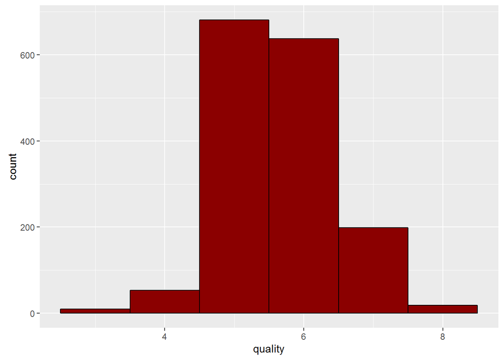

Wine quality is measured in integers with 0 being the worst and 10 being the best. All wines in this group fall between 3 and 8. Quality more or less seems to follow a normal distribution with most wines rating between 5 and 7. I wonder if I can find a relation between one or more variables and wine quality. I’m going to divide the wine into categories: bad, fair and good.

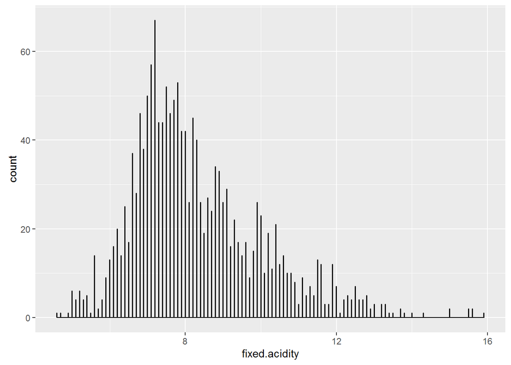

Fixed acidity for this sample ranges from 4.60 to 15.90 with most of the wines falling between 6 and 12. The histogram is slightly skewed to the right with a few outliers with fixed acidities higher than 12.

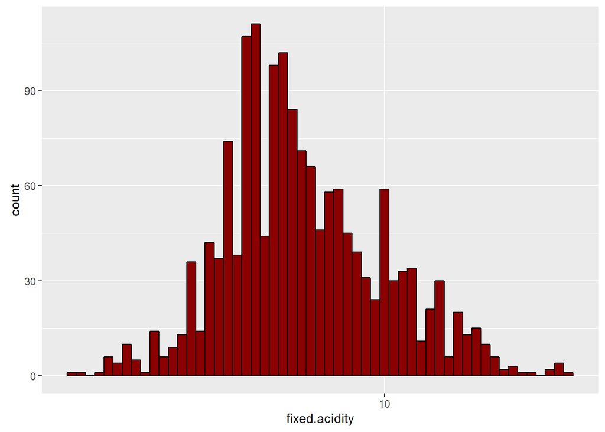

Since fixed acidity does not follow a normal distribution, I graphed the log 10 of it which is closer to a normal distribution.

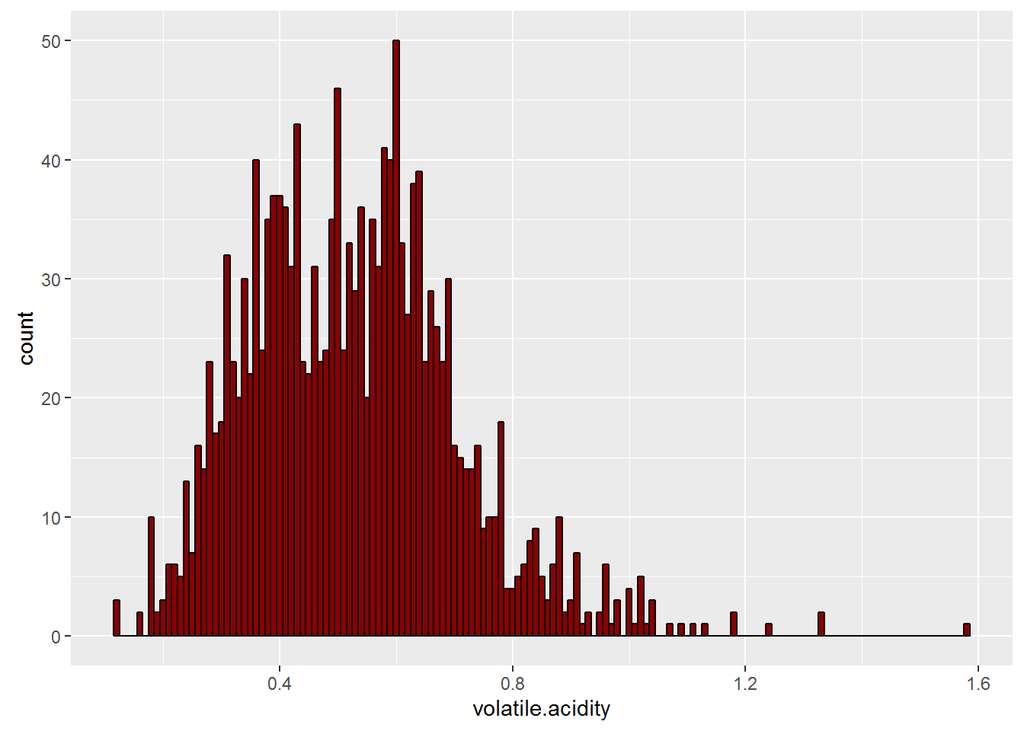

Volatile acidity for this sample ranges from 0.12 to 1.58 with most wines falling between 0.3 and 0.8. The data is slightly skewed to the right.

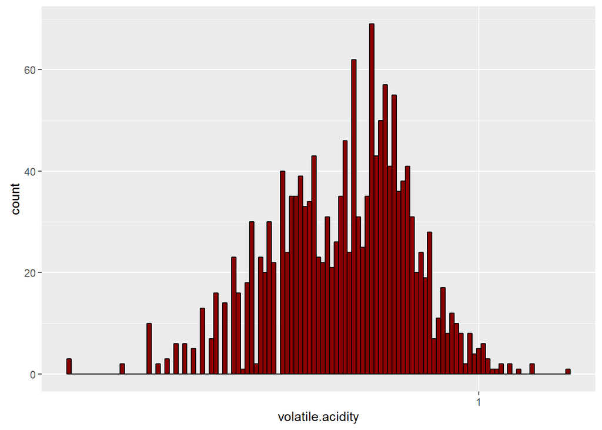

The log 10 graph of volatile acidity is closer to a normal distrbution.

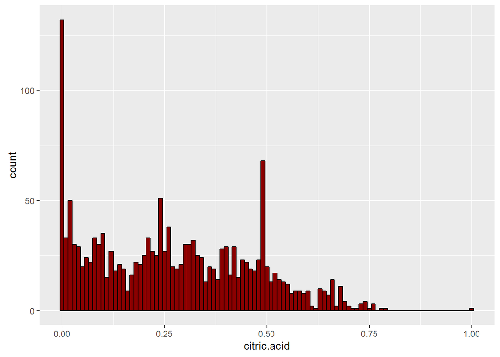

Citric acid ranges from 0 to 1 with most data falling between 0 to 0.6. The data is spread and slightly skewed to the right. There is a large count of wines that have a citric acid level of 0 or 0.5.

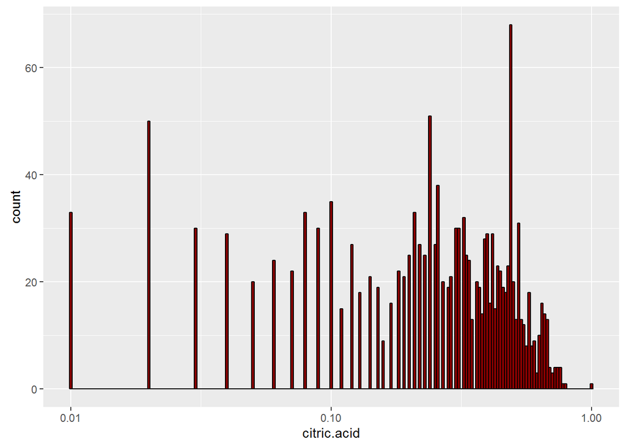

The log10 histogram of citric acid is not normally distributed.

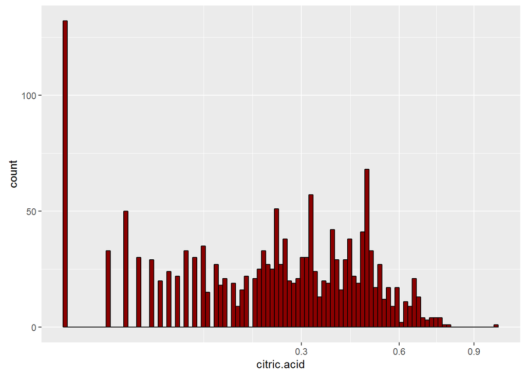

The square root of citric acid is not normally distributed either. There are too many zero values.

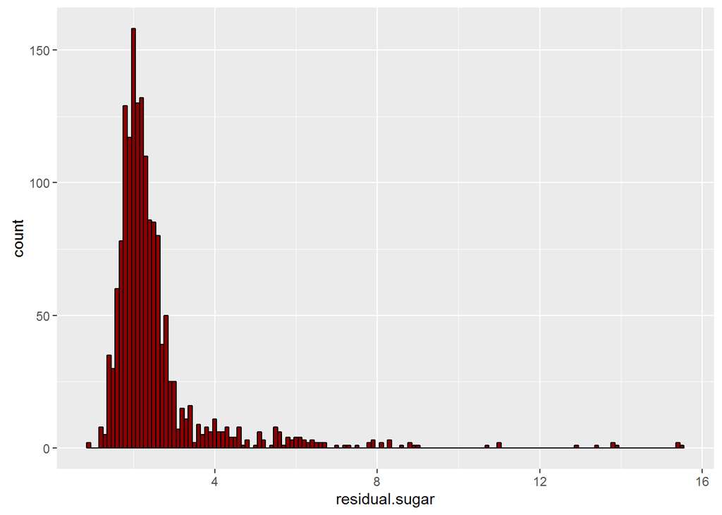

Residual sugar ranges from 0.9 to 15.5 with most wines falling between 1.6 and 5.1. The data is skewed to the right as a result of a few outliers.

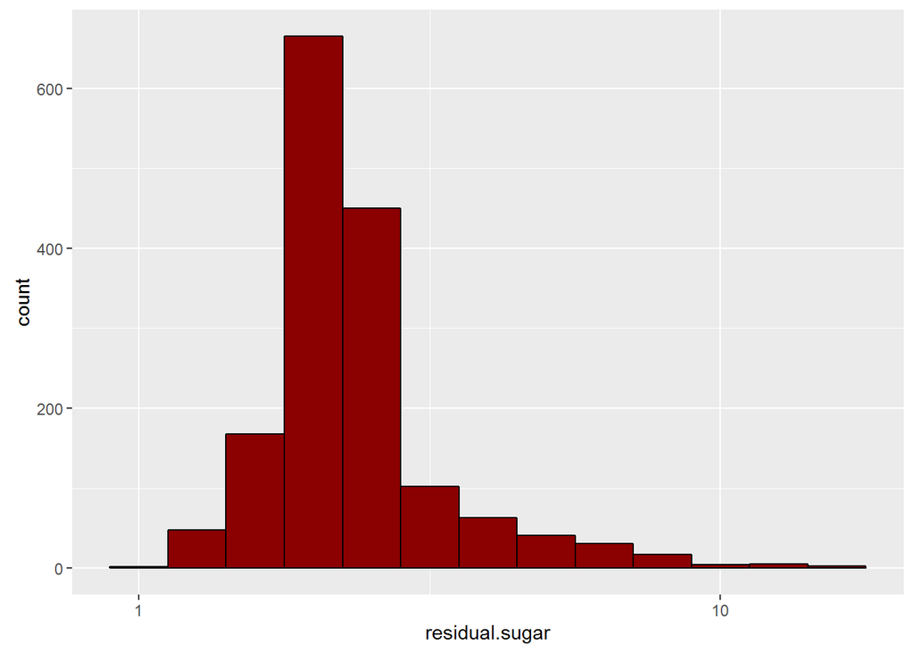

The log 10 of residual sugar is not normally distributed.

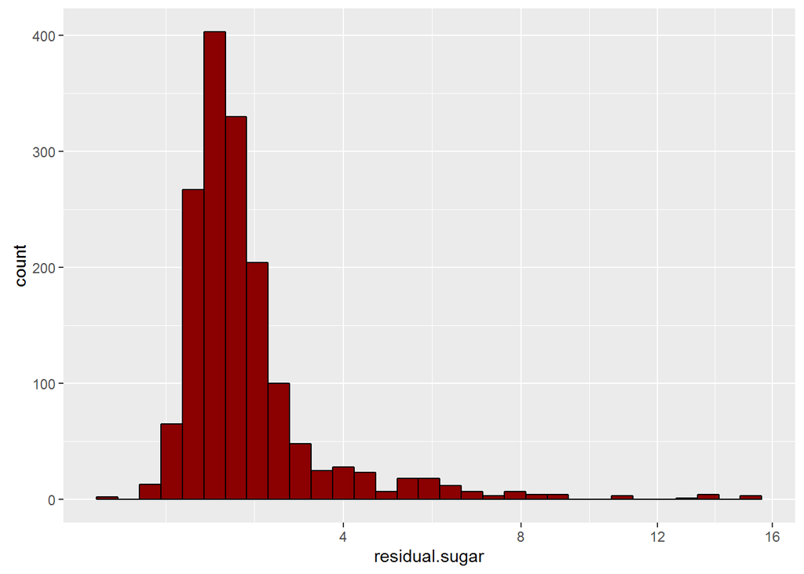

The square root of residual sugar is also not normally distributed.

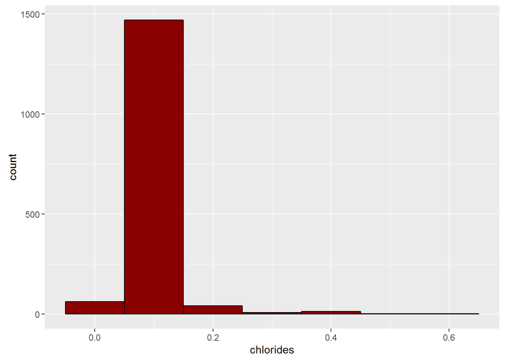

Chlorides from the samples range from 0.01 to 0.61 with most wine falling between 0.05 and 0.13. The data is skewed to the right due to a few outliers.

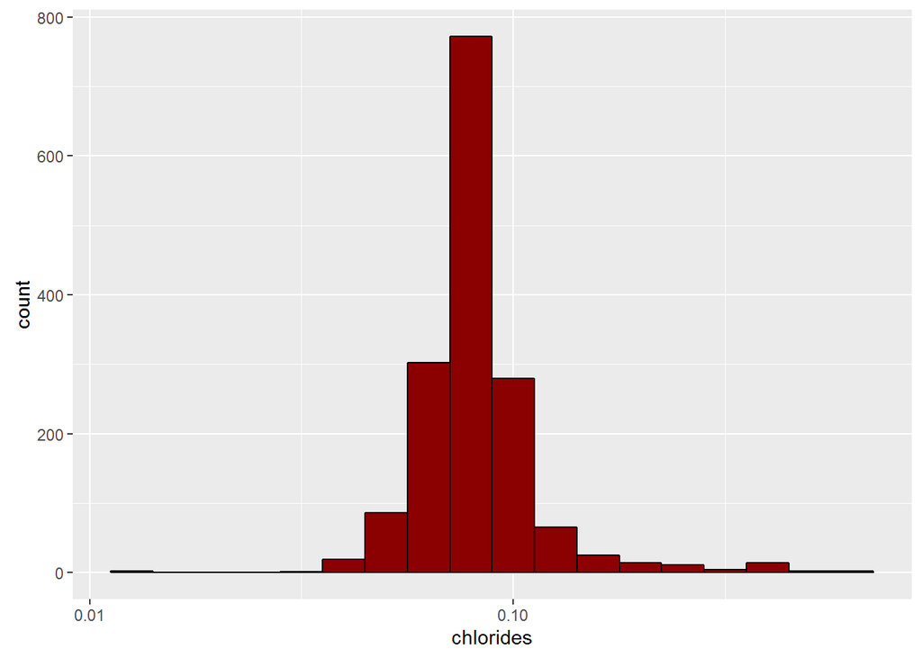

```r
hgraph10('chlorides',0.1)
```

The log 10 of chlorides is closer to a normal distribution.

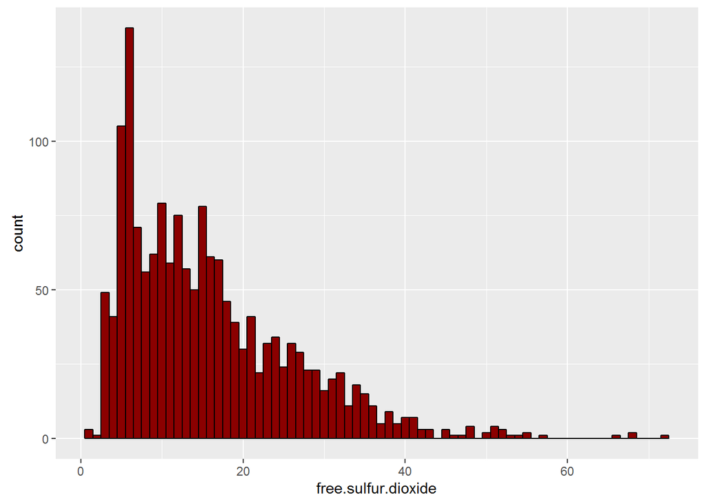

Free sulfur dioxide has a wide range of 1 to 72 with most wines falling between 4 and 35. The data is skewed to the right.

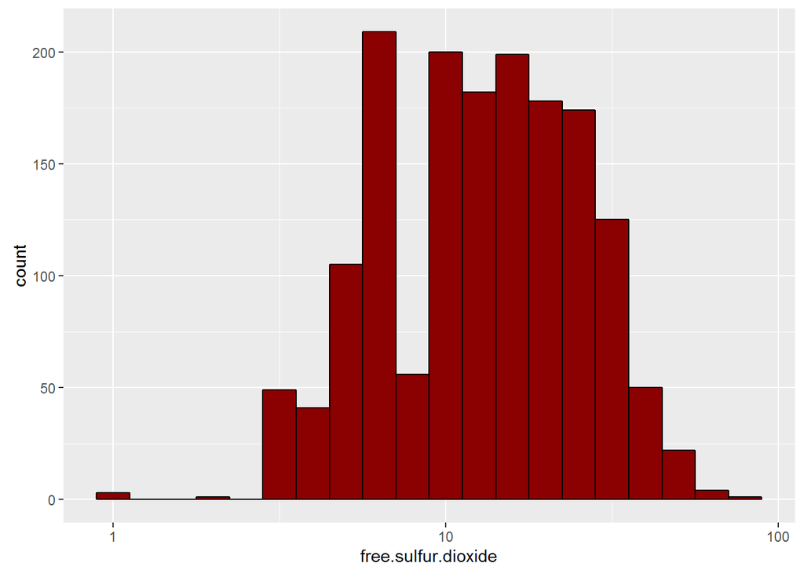

The log 10 of free sulfur dioxide is not normally distributed.

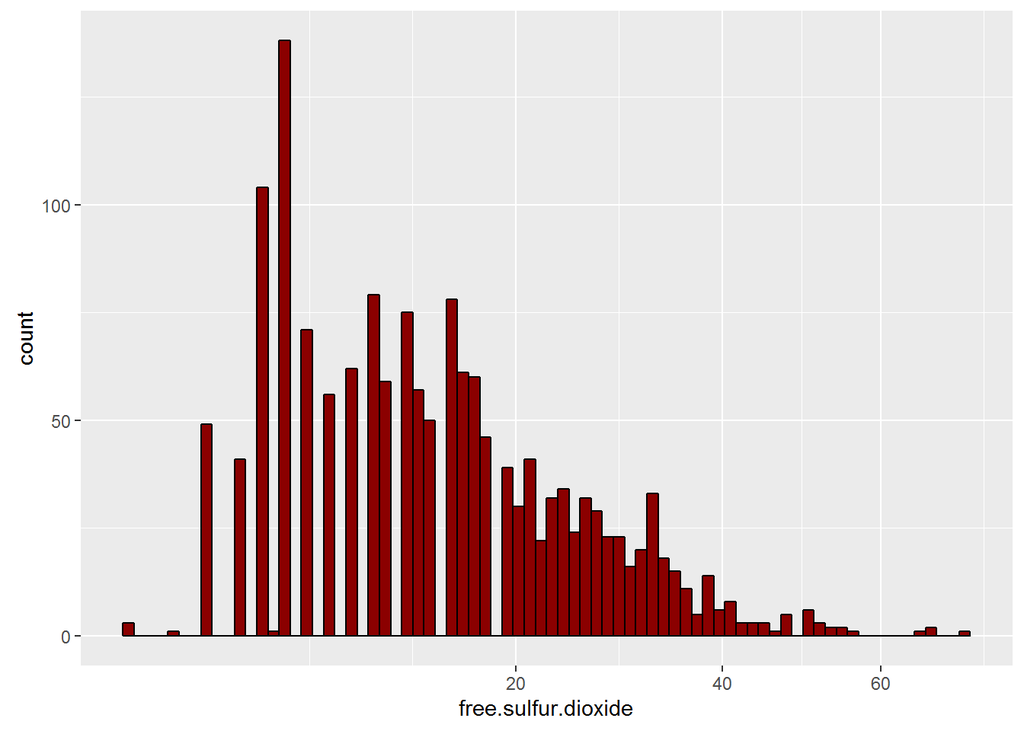

The square root of free sulfur dioxide is not normally distributed either.

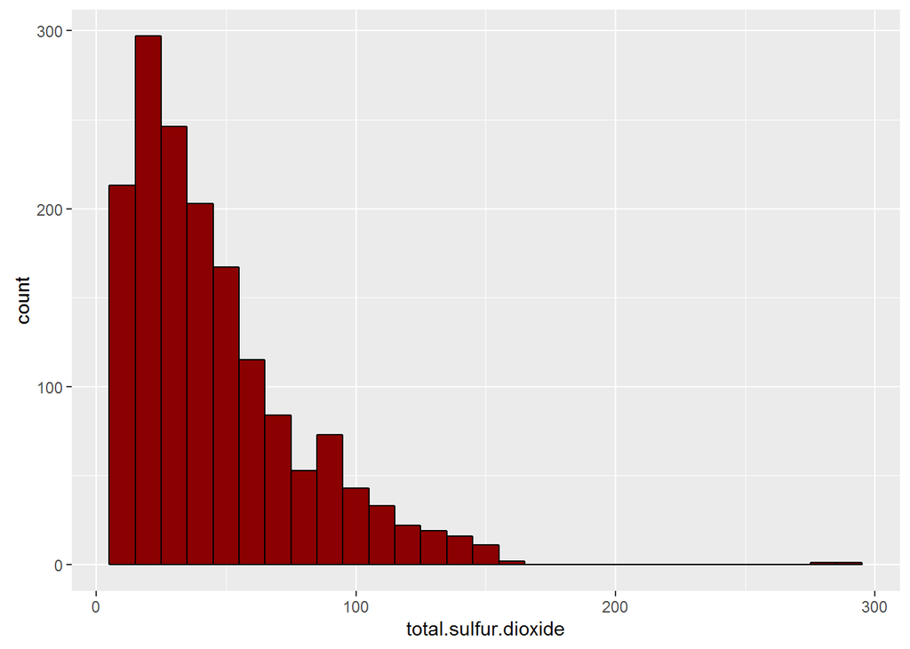

Total sulfur dioxide has an even wider range from 6 to 289 with most wine falling between 11 and 112. The data is skewed to the right.

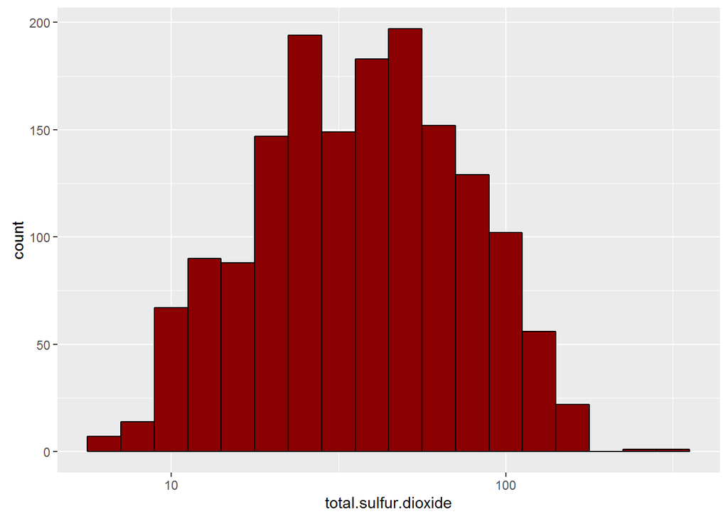

The log 10 of total sulfur dioxide is closer to a normal distribution.

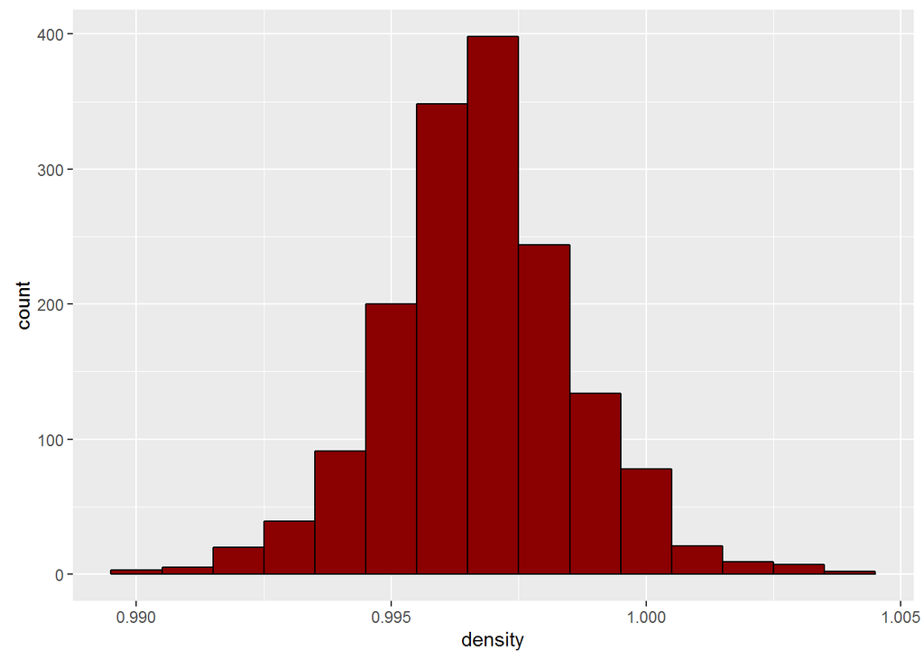

The data for density appears to follow a normal distribution with most wines falling between 0.994 and 1.

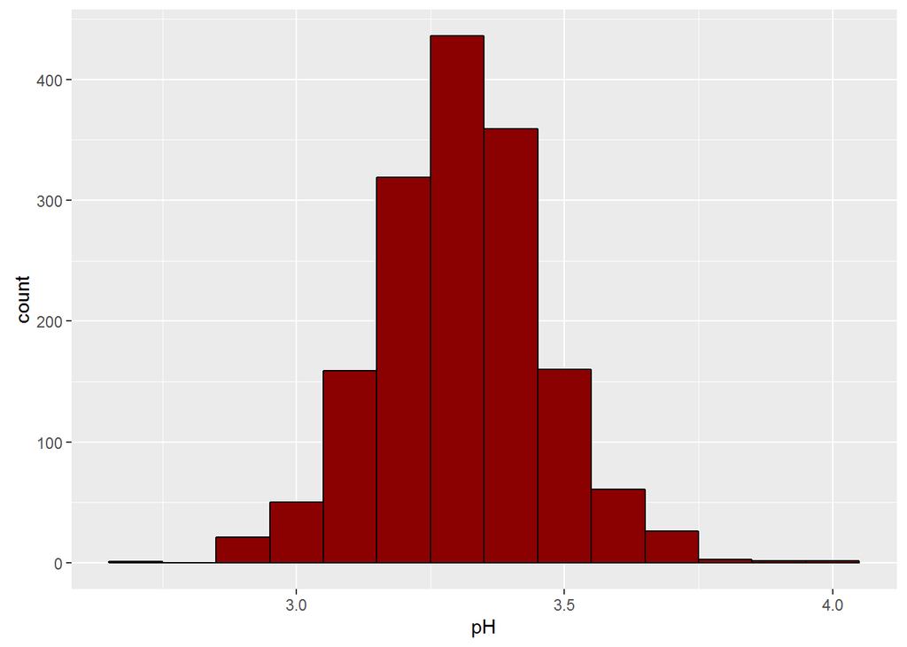

The pH data appears to follow a normal distribution with most wines falling between 3.0 and 3.6.

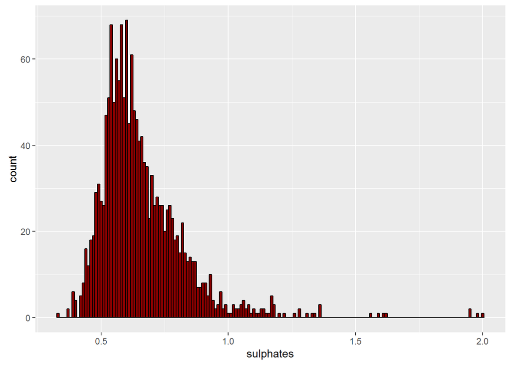

The sulphates data is skewed to the right, ranges from 0.33 to 2.00 with most wines falling between 0.47 and 0.93.

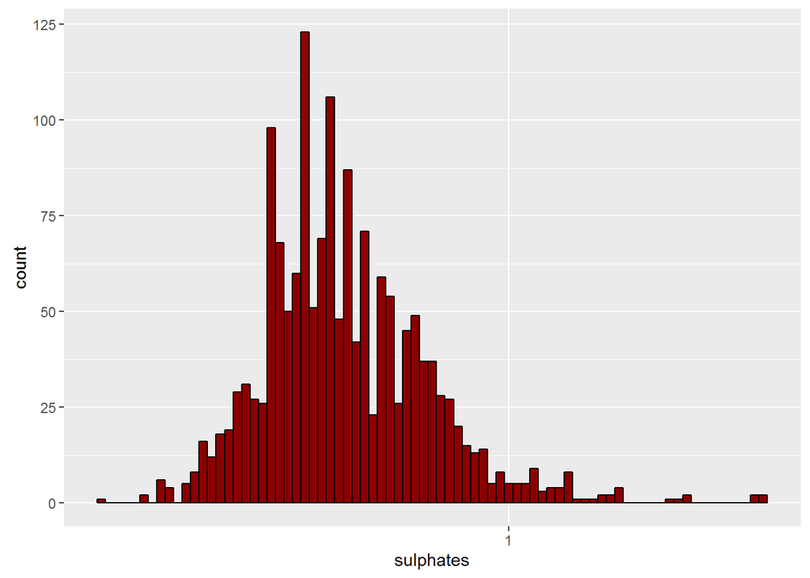

The log 10 of sulphates is closer to normally distributed.

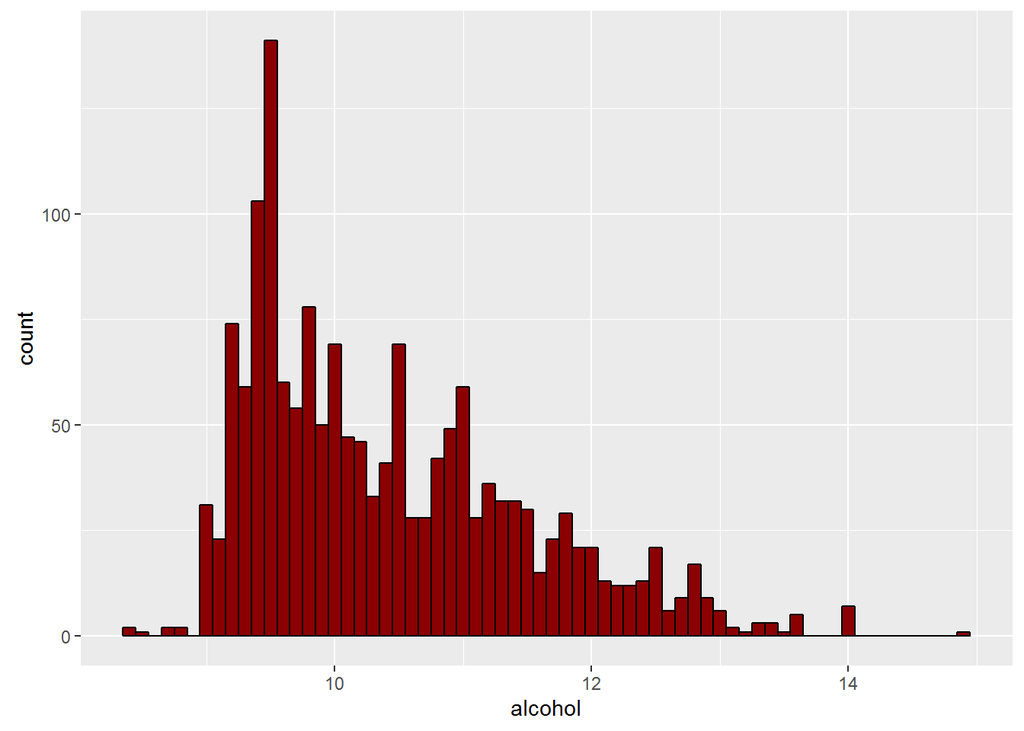

The alcohol data is skewed to the right and ranges from 8.4 to 14.9 with most data falling between 9.2 and 12.5.

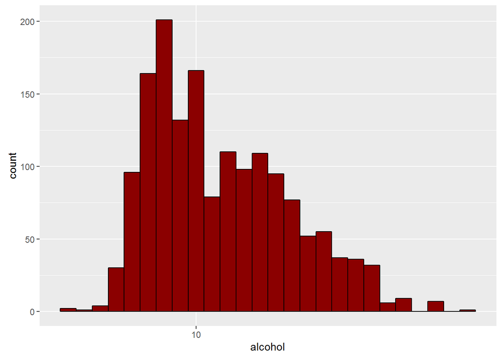

The log 10 of alcohol is skewed to the right.

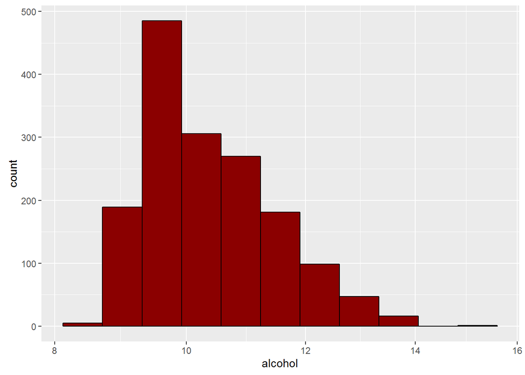

The square root of alcohol is also skewed to the right.

# Univariate Analysis

### What is the structure of your dataset?

There are 1599 wines in the dataset with 12 characteristics (fixed acidity, volatile acidity, citric acid, residual sugar, chlorides, free sulfur dioxide, total sulfur dioxide, density, sulphates, alcohol and quality).

Other observations: - Most wines have a quality between 5 and 7 which is not a wide range of qualities. - Most wine characteristics have a few outliers that measure high for that characteristic. - Many wines do have not citric acid.

### What is/are the main feature(s) of interest in your dataset?

The main feature of interest in the data set is quality. I’d like to determine which characteristics are best for predicting the quality of a wine.

### What other features in the dataset do you think will help support your investigation into your feature(s) of interest?

I suspect that good wines will not be highly acidic or sulfuric since many people find extremes of these tastes to be unpleasant.

### Of the features you investigated, were there any unusual distributions? Did you perform any operations on the data to tidy, adjust, or change the form of the data? If so, why did you do this?

# Bivariate Plots Section

I created boxplots of category and all variables to see if there is any difference between the categories.

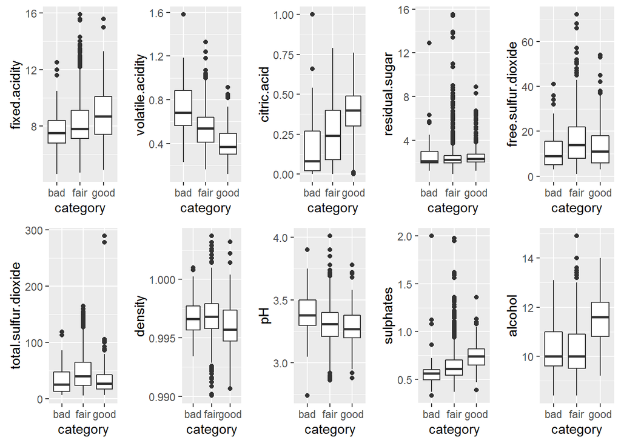

I created a corrplot matrix to quickly review relationships among all the variables.

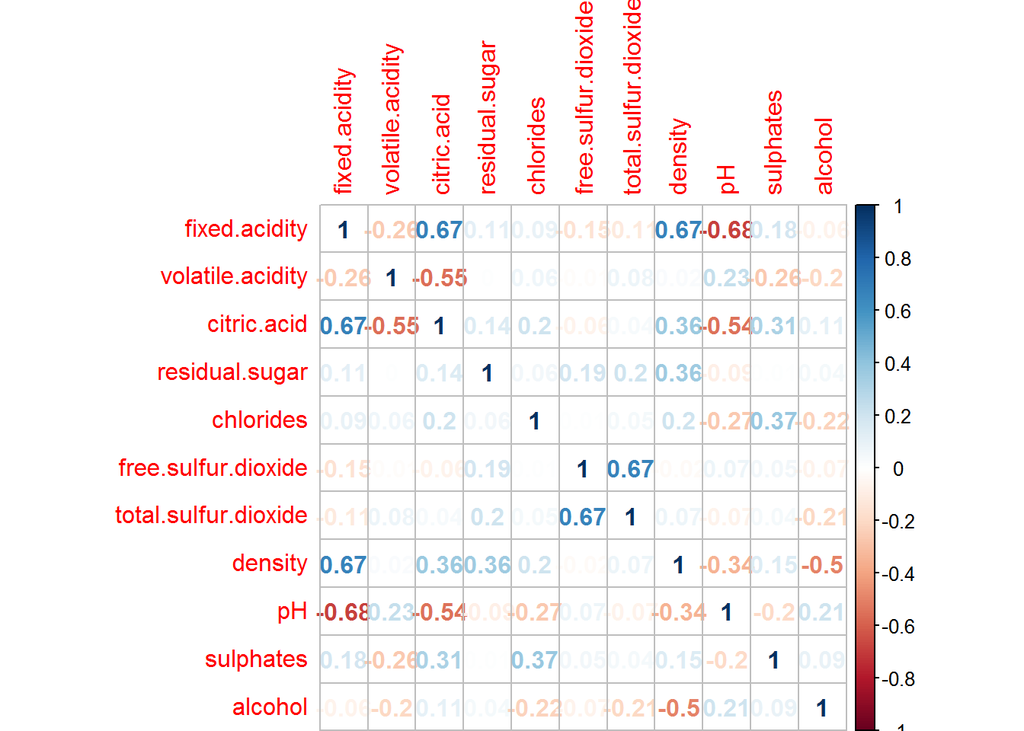

I recreated the graphs with correlation coefficients of greater than 0.5 or less than -0.5 for better viewing.

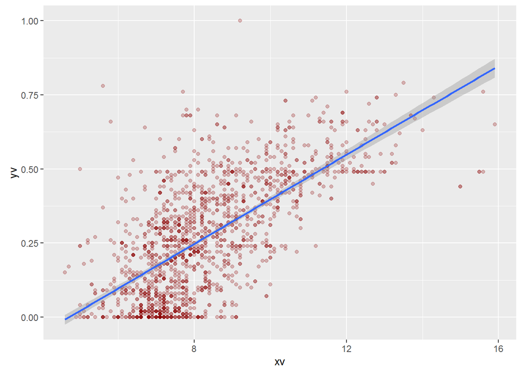